# Exercicio 9

Leticia Souza

## Vamos continuar trabalhando com os dados do ESEB 2018 e com o modelo anterior, utilizando aprovação de Bolsonaro como variável dependente (Q1607) e as variáveis ideologia (Q18), afinidade com o PT (Q1501), idade (D1A_ID), renda (D9), sexo (D2_SEXO) e cor/raça (D12A) como as independentes

```r
options(scipen = 999)

url <- "https://github.com/MartinsRodrigo/Analise-de-dados/raw/master/04622.sav"

download.file(url, "banco.sav", mode = "wb")

library(haven)
library(tidyverse)

banco <- read_sav("banco.sav") %>%
  mutate_all(zap_label) %>%
  select(Q1607, Q18, Q1501, D1A_ID, D9, D2_SEXO, D12A) %>%
  filter(Q1607 <= 10,
         D9 < 9999998,
         Q1501 <= 10,
         Q18 <= 10,
         D12A < 8) %>%
  mutate(D2_SEXO = as_factor(D2_SEXO),
         D12A = as_factor(D12A),
         Q18 = zap_labels(Q18),
         Q1501 = zap_labels(Q1501))

regressao <- lm(Q1607 ~ Q18 + Q1501 + D1A_ID + D9 + D12A + D2_SEXO, data = banco)

summary(regressao)
```

```
##
## Call:
## lm(formula = Q1607 ~ Q18 + Q1501 + D1A_ID + D9 + D12A + D2_SEXO,
##     data = banco)
##
## Residuals:
##     Min      1Q  Median      3Q     Max
## -8.4853 -2.6080  0.4114  2.1871  9.7386
##
## Coefficients:
##                    Estimate  Std. Error t value             Pr(>|t|)
## (Intercept)      4.39018088  0.40517187  10.835 < 0.0000000000000002 ***
## Q18              0.33229562  0.02618240  12.692 < 0.0000000000000002 ***
## Q1501           -0.39670681  0.02347407 -16.900 < 0.0000000000000002 ***
## D1A_ID           0.01410722  0.00578442   2.439               0.0149 *
## D9              -0.00005994  0.00002734  -2.192               0.0285 *
## D12APardo        0.60456532  0.26592237   2.273               0.0231 *
## D12ABranco       0.55238746  0.28563796   1.934               0.0533 .
## D12AAmarelo      1.26463377  0.58299415   2.169               0.0302 *
## D12AÍndio        0.82339434  0.50601096   1.627               0.1039
## D2_SEXOFeminino -0.71017594  0.17647379  -4.024            0.0000601 ***
## ---
## Signif. codes:  0 '***' 0.001 '**' 0.01 '*' 0.05 '.' 0.1 ' ' 1
##
## Residual standard error: 3.321 on 1431 degrees of freedom
## Multiple R-squared:  0.2915, Adjusted R-squared:  0.287
## F-statistic: 65.41 on 9 and 1431 DF,  p-value: < 0.00000000000000022
```

## Avalie a multicolinearidade da regressão e explique sua conclusão

```r
library(car)
vif(regressao)
```

```
##             GVIF Df GVIF^(1/(2*Df))
## Q18     1.030107  1        1.014942
## Q1501   1.070995  1        1.034889
## D1A_ID  1.010613  1        1.005293
## D9      1.051743  1        1.025545
## D12A    1.041352  4        1.005078
## D2_SEXO 1.015069  1        1.007506
```

O teste VIF(variance inflation factor) mede o quanto de multicolinearidade existe nas variáveis independentes. Quanto mais próximo de 1, menos multicolinearidade existe entre as variáveis. Se acordo com os resultados, as variáveis não possuem multicolinearidade, visto que todas as variáveis são ligeiramente maior que 1.

## Faça um gráfico de boxplot de cada uma das variáveis numéricas, e identifique a presença ou ausência de outliers

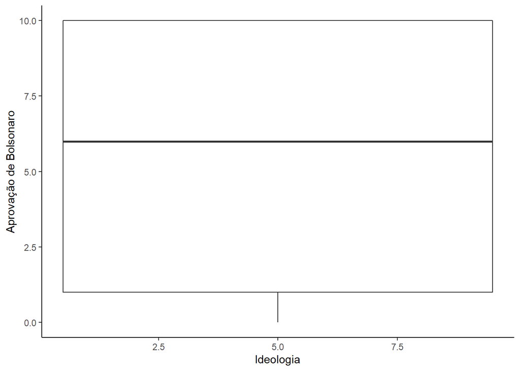

```r
ggplot(banco, aes(Q18, Q1607)) +
  geom_boxplot() +
  theme_classic() +
  labs(x = "Ideologia",
       y = "Aprovação de Bolsonaro")
```

O gráfico acima representa a relação entre aprovação de Bolsonaro e ideologia. Não há nenhum caso outlier.

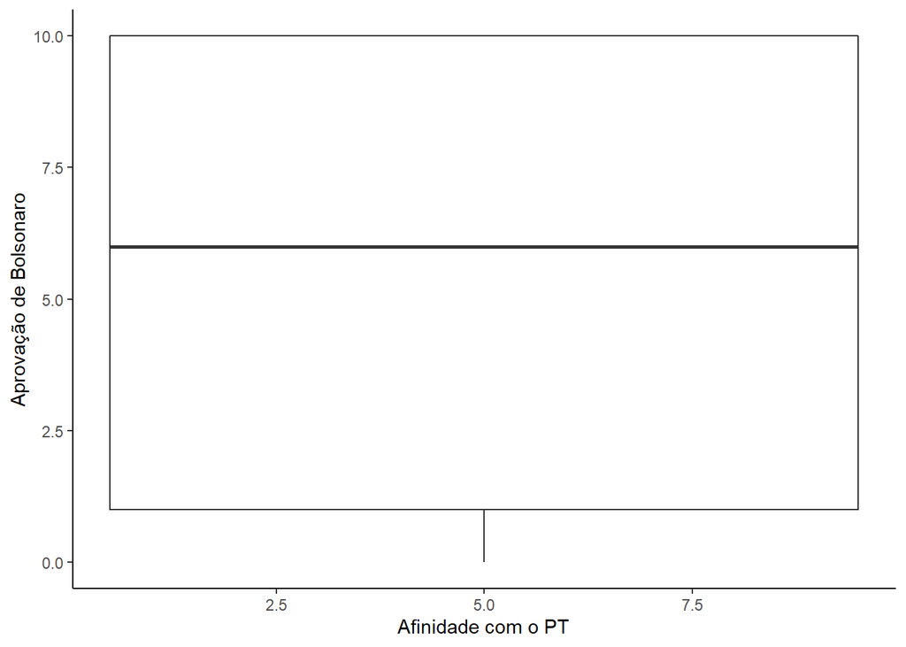

```r
ggplot(banco, aes(Q1501, Q1607)) +
  geom_boxplot() +
  theme_classic() +
  labs(x = "Afinidade com o PT",
       y = "Aprovação de Bolsonaro")
```

O gráfico acima representa a relação entre aprovação de Bolsonaro e afinidade com o PT. Não há nenhum caso outlier.

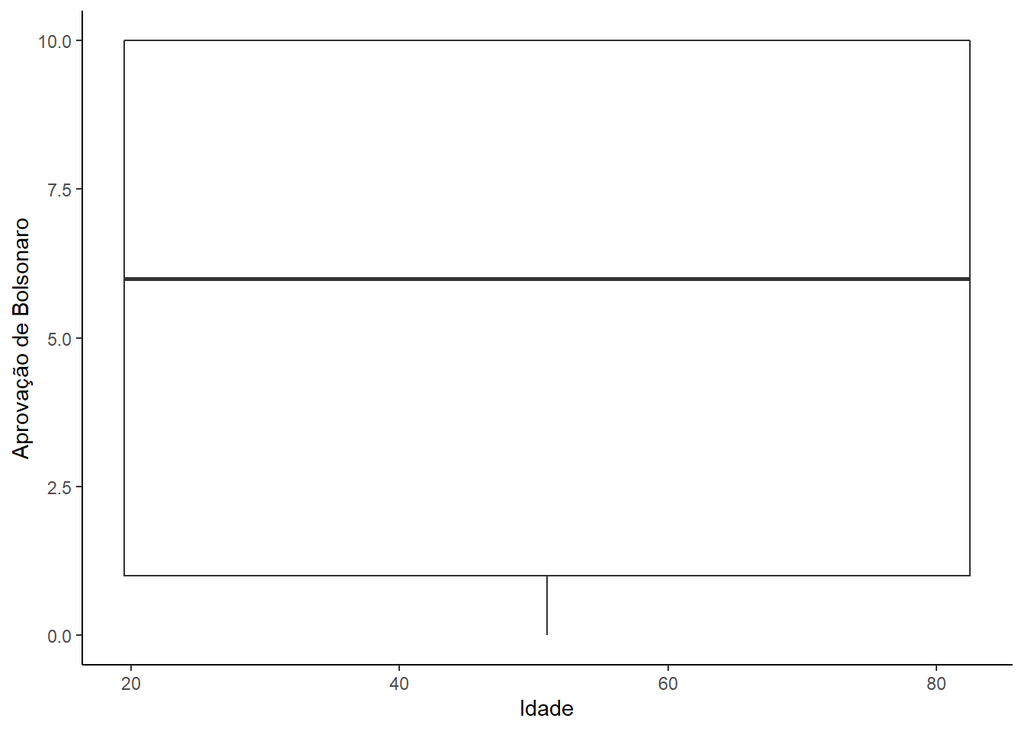

```r
ggplot(banco, aes(D1A_ID, Q1607)) +
  geom_boxplot() +
  theme_classic() +
  labs(x = "Idade",
       y = "Aprovação de Bolsonaro")
```

O gráfico acima representa a relação entre aprovação de Bolsonaro e idade. Não há nenhum caso outlier.

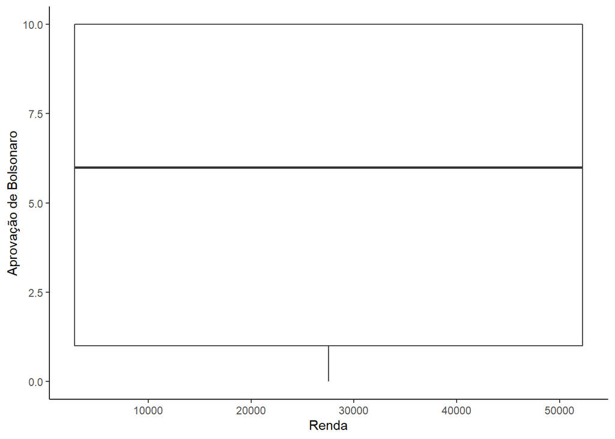

```r
ggplot(banco, aes(D9, Q1607)) +
  geom_boxplot() +
  theme_classic() +
  labs(x = "Renda",
       y = "Aprovação de Bolsonaro")
```

O gráfico acima representa a relação entre aprovação de Bolsonaro e renda. Não há nenhum caso outlier.

## Observe graficamente os resíduos do modelo e diga sua conclusão

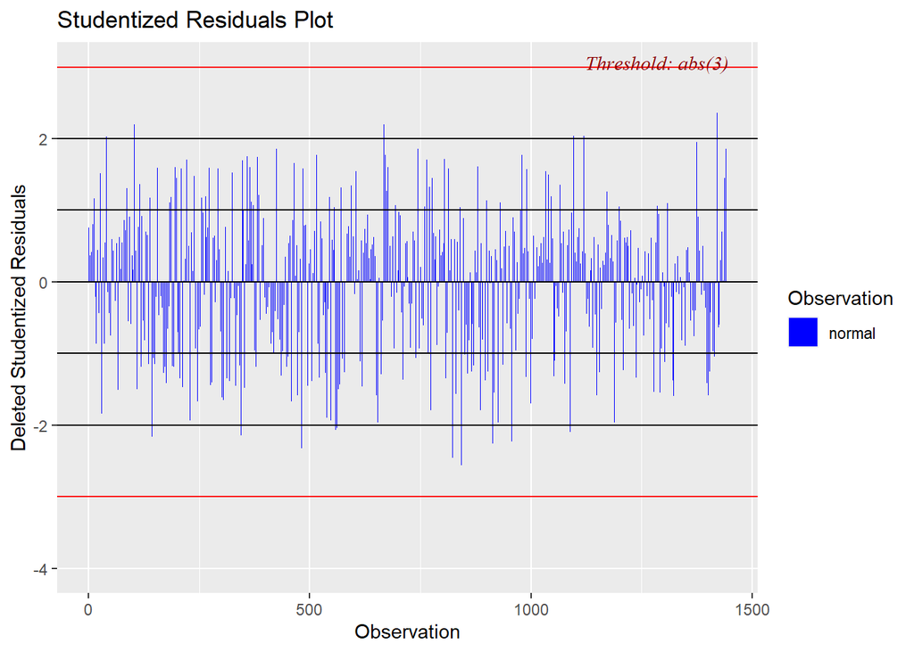

```r
library(olsrr)
ols_plot_resid_stud(regressao)
```

O gráfico apresenta os resíduos estudantilizados dos casos no modelo em azul. O threshold é 3, destacado pelas linhas vermelhas. Como nenhuma das barras azuis passa das linhas vermelhas, é possível dizar que não há resíduos distantes da média de erro.

## Observe graficamente a medida de Cook´s distance das observações e diga sua conclusão

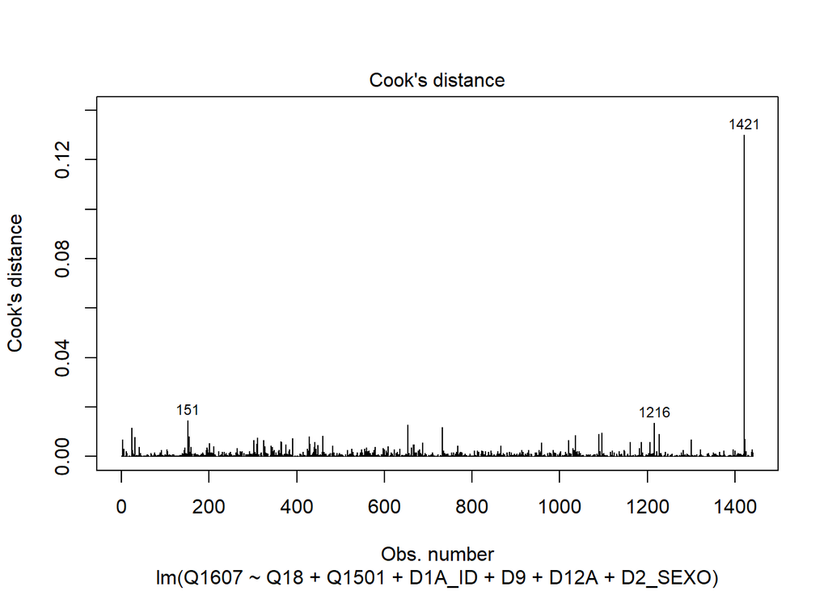

```r
plot(regressao, 4)
```

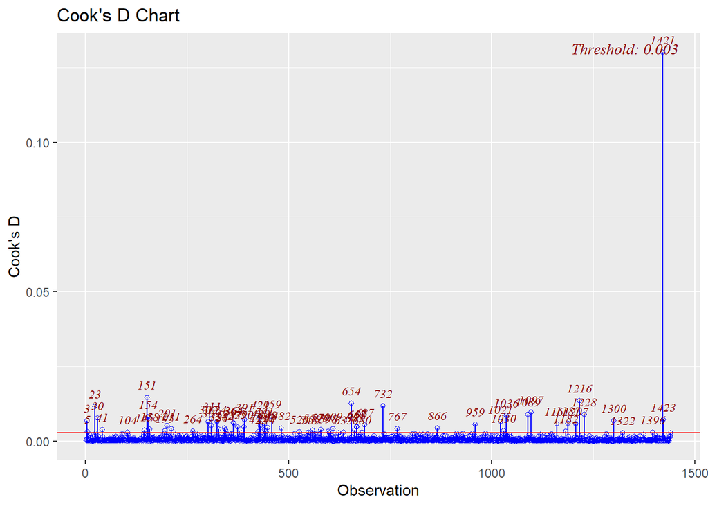

```r
ols_plot_cooksd_chart(regressao)
```

Os dois gráficos apresentam casos influentes, ou seja, casos que modificam muito os coeficientes estimados, erro padrão e/ou R² da regressão. A linhas verticais são casos e, quanto mais altas forem, mais influente são esses casos. No gráfico 2, um threshold é adicionado, esta linha vermelha. Nele, as linhas azuis que ultrapassarem a linha vermelha indicam casos potencialmente influentes. Portanto, apesar dos resíduos estarem dentro da média e não haver outliers nas fases anteriores, há alguns casos influentes. O caso 1421 é bastante influente.

## Faça os gráficos de resíduos x leverage e diga sua conclusão

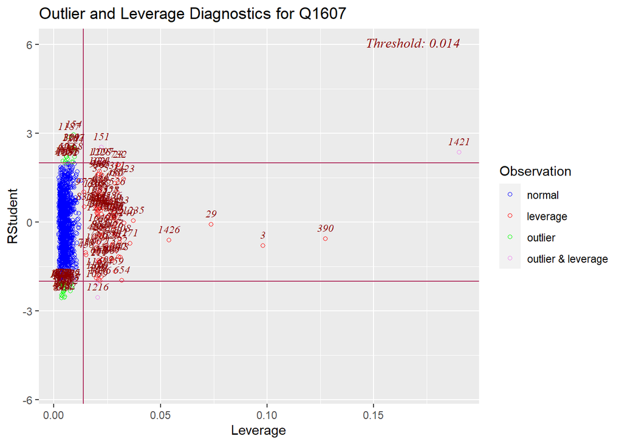

```r
ols_plot_resid_lev(regressao)
```

## Faça o gráfico que exiba o DFFITS e diga sua conclusão

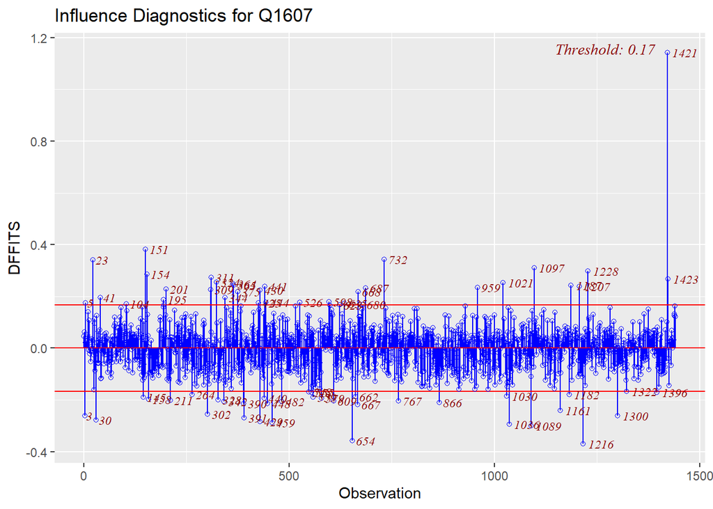

```r
ols_plot_dffits(regressao)
```

Neste gráfico, as linhas azuis de casos que ultrapassam os tresholds indicados pelas linhas vermelhas são considerados casos influentes. Esse teste indica a diferença da média de erro quando casos influentes são retirados. O caso 1421 é bastante influente.

## Faça o gráfico que exiba o DFBETAS e diga sua conclusão

```
## $plots
## $plots[[1]]
```

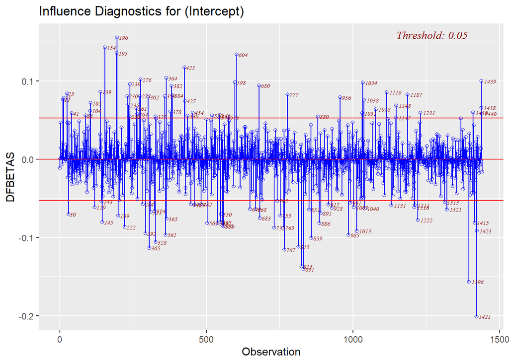

```
##
## $plots[[2]]
```

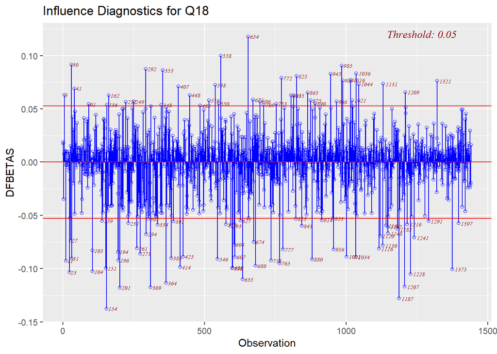

```
##
## $plots[[3]]
```

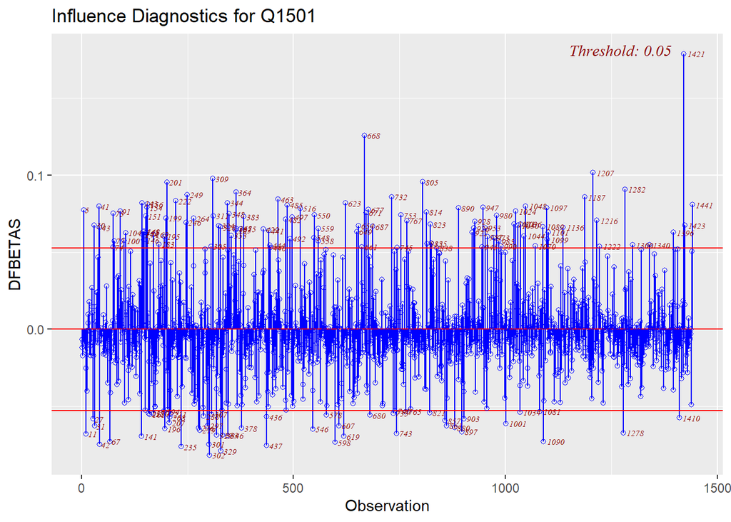

```
##
## $plots[[4]]
```

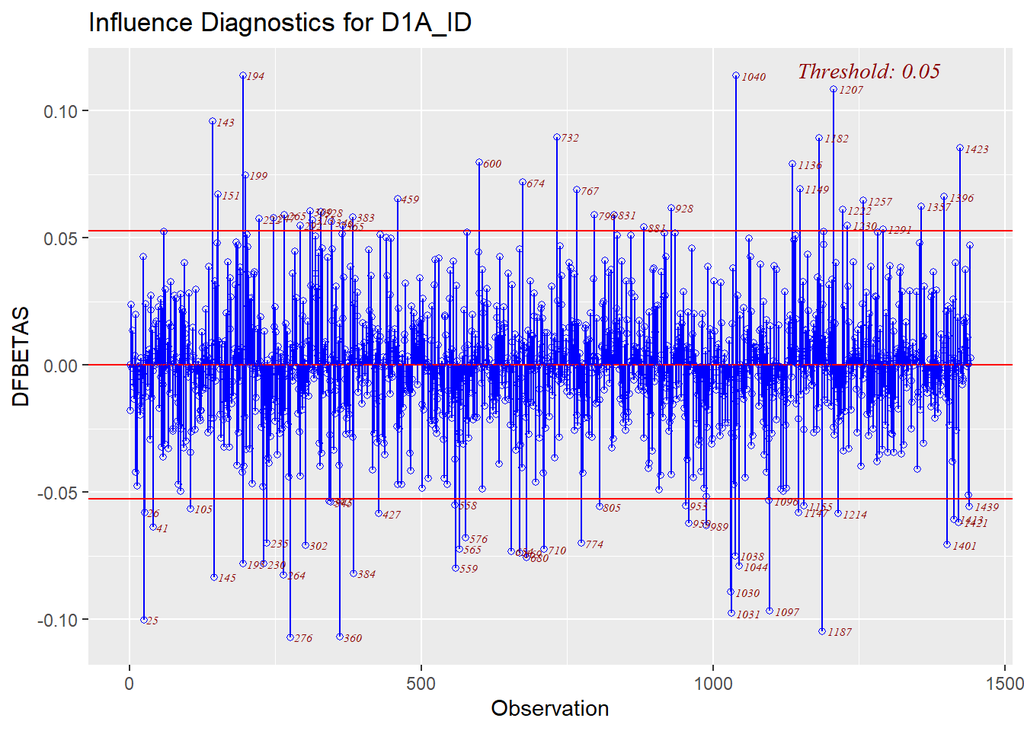

```
##
## $plots[[5]]
```

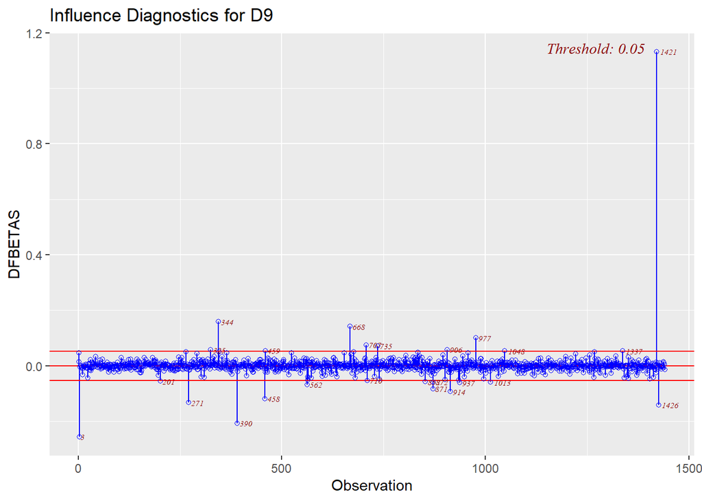

```
##
## $plots[[6]]
```

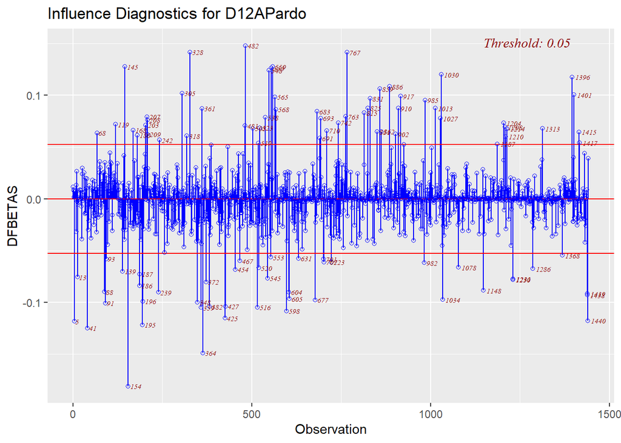

```
##
## $plots[[7]]
```

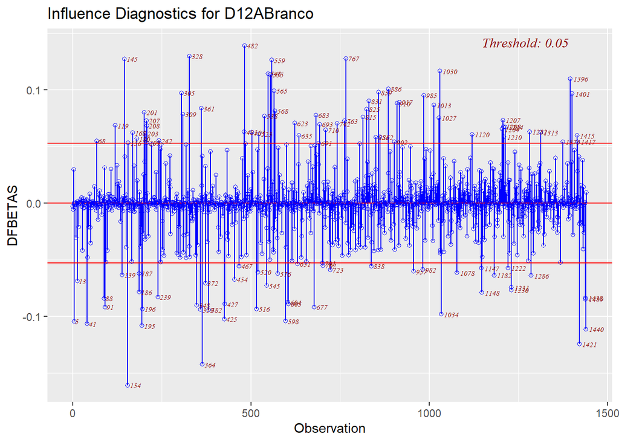

```
##
## $plots[[8]]
```

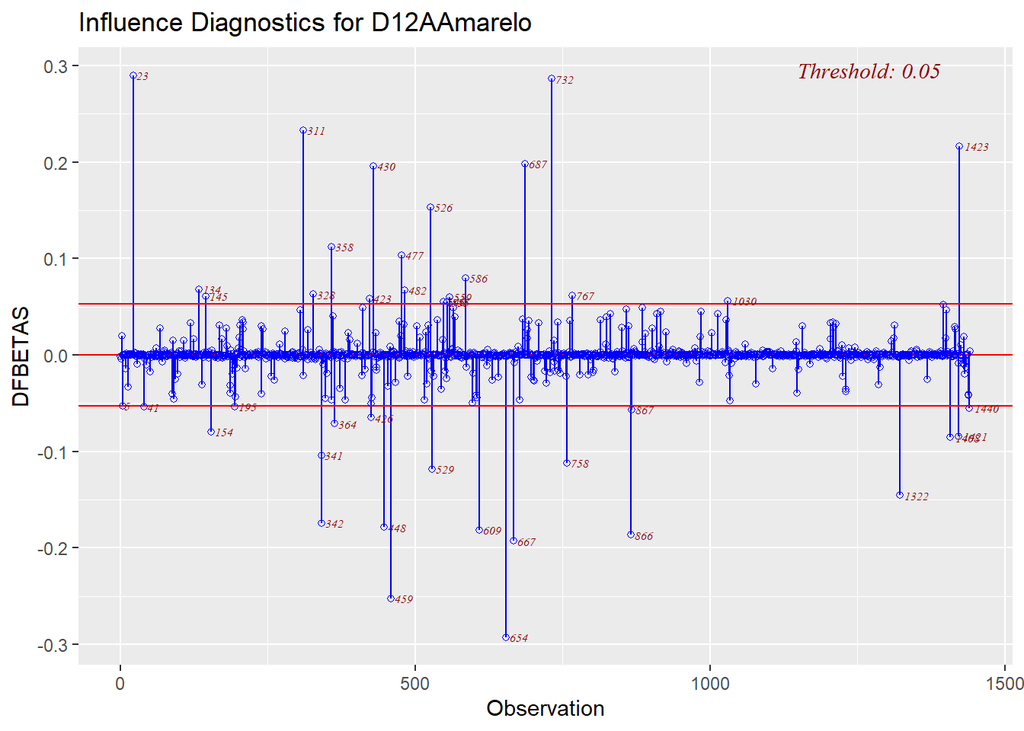

```
##
## $plots[[9]]
```

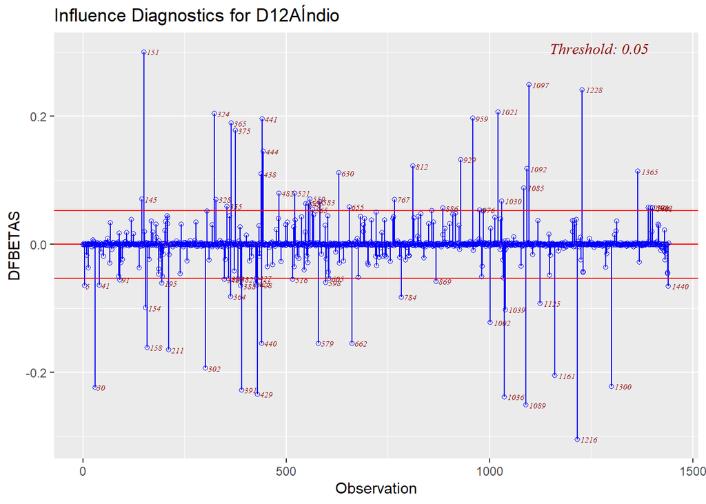

```
##
## $plots[[10]]
```

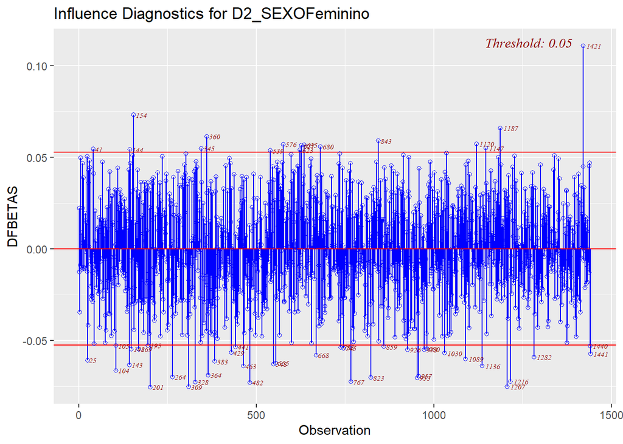

[output not shown]

[output cut: 866 more lines]

```r
ols_plot_dfbetas(regressao, print_plot = F)
```

Esse teste indica a diferença nos betas das variáveis quando casos influentes são retirados. Com exceção da variável renda, com apenas alguns, todas as variáveis apresentam muitos casos influentes. O caso 1421 se reprete como um caso bastante influente na maioria deles.

## Faça uma regressão eliminando a observação que você considera mais influente e comente as diferenças no resultado da regressão

```r
banco2 <- banco %>%
  slice(-1421)

regressao2 <- lm(Q1607 ~ Q18 + Q1501 + D1A_ID + D9 + D12A + D2_SEXO, banco2)
summary(regressao2)
```

```
##
## Call:
## lm(formula = Q1607 ~ Q18 + Q1501 + D1A_ID + D9 + D12A + D2_SEXO,
##     data = banco2)
##
## Residuals:
##     Min      1Q  Median      3Q     Max
## -8.5046 -2.5755  0.4079  2.1797  9.7196
##
## Coefficients:
##                    Estimate  Std. Error t value             Pr(>|t|)
## (Intercept)      4.47146913  0.40599346  11.014 < 0.0000000000000002 ***
## Q18              0.33125289  0.02614451  12.670 < 0.0000000000000002 ***
## Q1501           -0.40089416  0.02350391 -17.056 < 0.0000000000000002 ***
## D1A_ID           0.01446434  0.00577720   2.504              0.01240 *
## D9              -0.00009086  0.00003029  -3.000              0.00275 **
## D12APardo        0.60976915  0.26550871   2.297              0.02179 *
## D12ABranco       0.58792518  0.28558163   2.059              0.03970 *
## D12AAmarelo      1.31376143  0.58243981   2.256              0.02425 *
## D12AÍndio        0.82283765  0.50520643   1.629              0.10359
## D2_SEXOFeminino -0.72972554  0.17638808  -4.137            0.0000372 ***
## ---
## Signif. codes:  0 '***' 0.001 '**' 0.01 '*' 0.05 '.' 0.1 ' ' 1
##
## Residual standard error: 3.316 on 1430 degrees of freedom
## Multiple R-squared:  0.2941, Adjusted R-squared:  0.2896
## F-statistic: 66.19 on 9 and 1430 DF,  p-value: < 0.00000000000000022
```

```r
summary(regressao)
```

```
##
## Call:
## lm(formula = Q1607 ~ Q18 + Q1501 + D1A_ID + D9 + D12A + D2_SEXO,
##     data = banco)
##
## Residuals:
##     Min      1Q  Median      3Q     Max
## -8.4853 -2.6080  0.4114  2.1871  9.7386
##
## Coefficients:
##                    Estimate  Std. Error t value             Pr(>|t|)
## (Intercept)      4.39018088  0.40517187  10.835 < 0.0000000000000002 ***
## Q18              0.33229562  0.02618240  12.692 < 0.0000000000000002 ***
## Q1501           -0.39670681  0.02347407 -16.900 < 0.0000000000000002 ***
## D1A_ID           0.01410722  0.00578442   2.439               0.0149 *
## D9              -0.00005994  0.00002734  -2.192               0.0285 *
## D12APardo        0.60456532  0.26592237   2.273               0.0231 *
## D12ABranco       0.55238746  0.28563796   1.934               0.0533 .
## D12AAmarelo      1.26463377  0.58299415   2.169               0.0302 *
## D12AÍndio        0.82339434  0.50601096   1.627               0.1039
## D2_SEXOFeminino -0.71017594  0.17647379  -4.024            0.0000601 ***
## ---
## Signif. codes:  0 '***' 0.001 '**' 0.01 '*' 0.05 '.' 0.1 ' ' 1
##
## Residual standard error: 3.321 on 1431 degrees of freedom
## Multiple R-squared:  0.2915, Adjusted R-squared:  0.287
## F-statistic: 65.41 on 9 and 1431 DF,  p-value: < 0.00000000000000022
```

As mudanças são pequenas, já que há vários casos influentes e apenas um foi retirado, mas é possível observar mudanças na significância dos coeficientes, nos betas em si, na média dos resídios e no R².